# Part II - FordGoBikes Analysis.

## by (Tamuno-omi Jaja )

## Investigation Overview

> Ford GoBikes is a Bike sharing system that was renamed Bay Wheels in June 2019, after its acquisation by Lyft, It is based in the San Francisco Bay Area, California. In this investigation, I've looked at the bike ride trends and biker type of the bay Ford GoBike Share system. The main interest was to understand the relationship between biking duration & other trip information with focus on distance, the time (weekday, hour), and the user types.

## Dataset Overview

> The Ford GoBike System data includes information about individual rides covering the greater San Francisco Bay area, The dataset contains 183,412 individual rides and 16 features that outline customer information, the ride duration and start-end destination.

### Distribution of Ride Duration (mins)

From the Visualization we can see that most rides are between three to twelve minutes and that Duration(min) is Right Skewed, pointing to a user preference for shorter trips.

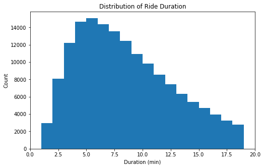

```python
# investigating  Ride duration with  smaller bin size
binsize = 1
bins = np.arange(0, 20, 1)

plt.figure(figsize=[8, 5])
plt.hist(data = bike_df, x = 'duration_min', bins = bins)
plt.xlim([0,20])
plt.xlabel('Duration (min)')
plt.ylabel('Count')
plt.title('Distribution of Ride Duration')
plt.show()
```

### Distribution of Ride Distance (km)

The distance is the length of space between the Start and End Station, the limits of the visual is reduced to exclude outliers, the distribution looks roughly bimodal, with one peak between 0.8 and 1 km, and a second peak a little below 1.5 km. Futher evidence of users taking mainly short trips.

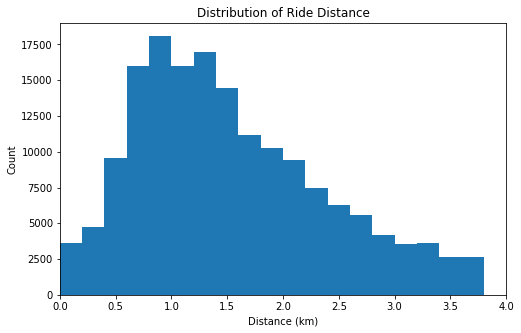

```python
# investigating distance
bins = np.arange(0, 4, 0.2)
plt.figure(figsize=[8, 5])
plt.hist(data = bike_df, x = 'distance_km', bins = bins)
plt.xlim([0,4])
plt.xlabel('Distance (km)')
plt.ylabel('Count')
plt.title('Distribution of Ride Distance')
plt.show()
```

### Max previous rides and Average Duration for Bike

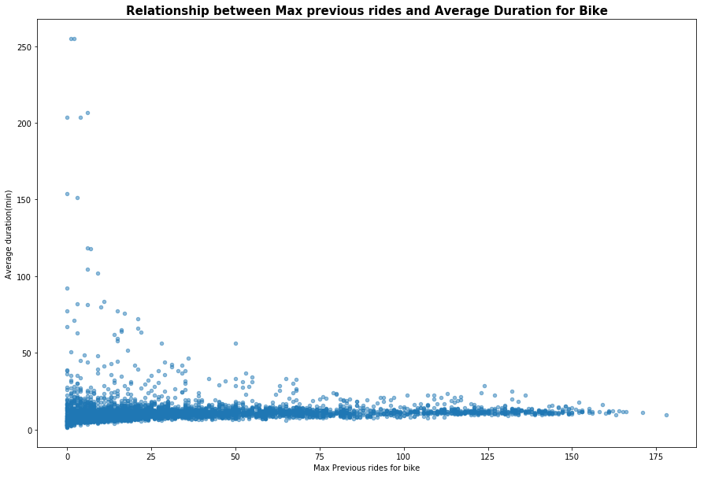

```python
# Get max_number of previous ride taken by each bike
bike_rides = bike_df.groupby(['bike_id'], sort=False)['previous_bike_rides'].max().reset_index()

# Relationship between Max previous rides and Average bike Duration
bike_duration = bike_df.groupby('bike_id')['duration_min'].mean().reset_index()
bike_info = bike_rides.merge(bike_duration, left_on = 'bike_id', right_on = 'bike_id', how = 'inner').rename(columns={"previous_bike_rides": "max_previous_rides","duration_min":"bike_avg_duration_min"})
bike_info.head()

#scatterplot
x = bike_info.plot(kind = 'scatter', x = 'max_previous_rides', y = 'bike_avg_duration_min', figsize = (15,10), alpha = 0.5)
x.grid(False)
plt.xlabel('Max Previous rides for bike')
plt.ylabel('Average duration(min)')
plt.title('Relationship between Max previous rides and Average Duration for Bike', weight='bold', fontsize=15);
```

### Ford GoBikes Sharing Customer vs. Subscribers Trends in 2019 Weekdays vs Ride Duration

Ride duration for both Member groups( Customer & Subscriber ) peaks during weekends, probably because members aren't in a rush to get to their destination, unlike normal working days.

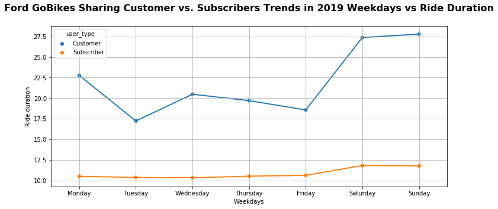

```python
plt.figure(figsize=(12, 5))

df_cleaned_user_week = bike_df.groupby(['day', 'user_type'])['duration_min'].mean().reset_index()
weekday = ['Monday', 'Tuesday', 'Wednesday', 'Thursday', 'Friday', 'Saturday', 'Sunday']

ax = sb.pointplot(data=df_cleaned_user_week, x='day', y='duration_min', hue = 'user_type', scale=.7,order = weekday);


plt.title('Ford GoBikes Sharing Customer vs. Subscribers Trends in 2019 Weekdays vs Ride Duration', y=1.07, fontsize=16, fontweight='bold')
plt.xlabel('Weekdays')
plt.ylabel('Ride duration');
plt.grid()
plt.show()
```